# Anatomie d’un modèle de décompression : le DCIEM

(versions KS-1971 et DCIEM 1983)

Pascal Monestiez  
octobre 2026  
Version détaillée et approfondie

## Origine du DCIEM - l’environnement

- **DCIEM n’est pas à l’origine le nom d’un modèle**, mais celui de l’institut où il a été conçu : **Defence and Civil Institute of Environmental Medicine**, Downsview, Ontario, Canada
- **Nombreux travaux sur les modèles de décompression dans les années 60–80** pour améliorer les tables (Workman 1965, Bühlmann 1969, Hennessy and Hempleman 1977, Yount and Hoffman -VPM- 1986, Wienke RGBM 1990). **Le DCIEM naît à cette période**
- **Apparition des décompressimètres « analogiques »** (pneumatic decompression computer) dans les 70’s et modélisation physique de ces « décompressimètres » **(Hills B.A. 1967)** par équations de diffusion

[figure not shown]

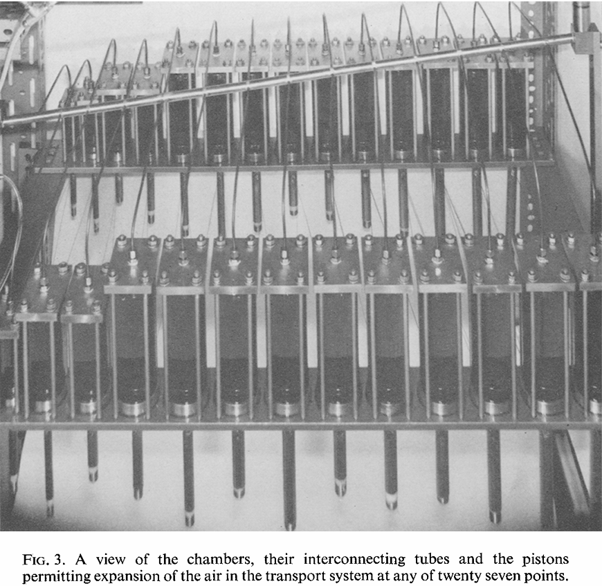

Pascal Monestiez, octobre 2026, CC BY NC

## Origine du DCIEM - la naissance

- **Les travaux de Kidd, Weaver, Kuehn et Stubbs (1965, 1968)**, Hempleman (1960), Dieter (1967), Thalmann (1997) remettent en cause le modèle exponentiel de Haldane (perfusion - symétrie de la saturation et de la désaturation). Les premiers proposent une **nouvelle forme d’équation basée sur les travaux de Hills**
- L’équation est reprise par **Kidd et Stubbs (1969)** pour une **première version du modèle (appelée KS-1971 par la suite)**, dont le code est publié en 1973 par Nishi et Kuehn
- **Le projet est de concevoir un ordinateur numérique de plongée**, ce qui implique des algorithmes simplifiés, peu de paramètres et un pas de temps d’une minute (principe de parcimonie du fait de la puissance des calculateurs de l’époque).

**Hills B.A (1967)** A pneumatic analogue for predicting the occurrence of decompression sickness. J. of Medical and biological Engeneering, 5, 421-432

**Kidd D.J. and Stubbs R.A. (1969)** The use of the pneumatic analog computer for divers, in P.B. Bennett and D.H. Elliott, Eds., The Physiology and Medicine of Diving and Compressed Air Work, 1st ed., pp. 386-413, Bailliere, Tindall and Cassell, London. 1969.

**Weaver R.S., Kuehn L.A. and Stubbs R.A. (1968)** Decompression calculations: analogue and digital methods. DRET Report 703,  
Defence Research Establishment, Toronto.

Pascal Monestiez, octobre 2026, CC BY NC

## Origine du DCIEM - la maturité

- Le but était d’être **aussi conservatif que les tables** de l’époque (Royal Navy, US Navy). Le KS-1971 semble trop conservatif pour les plongées courtes peu engagées et pour les plongées très longues et engagées
- **Le KS-1971 est modifié** en conséquence par Nishi et Lauckner (1984) et **produit le DCIEM 1983 model**. Il donnera les tables **DCIEM Diving Manual** (1986, 1ère Ed.) comme sous-produit du modèle…
- **Validations dans les années 70’s et 80’s** pour une très grande gamme de profils et de conditions *(détails sur les essais plus loin dans l’exposé)*

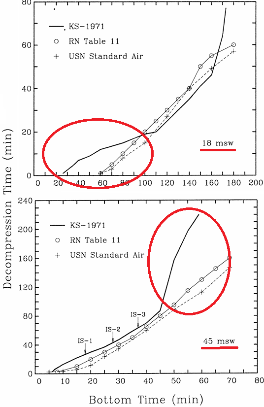

**Nishi R. Y. and Lauckner G.R. (1984)** Development of the DCIEM 1983 decompression model for compressed air diving.  
DCIEM No. 84-R-44, Defence and Civil Institute of Environmental Medicine, Downsview, Ontario, pp. 54.

Pascal Monestiez, octobre 2026, CC BY NC

## Modèle de saturation/désaturation en série

- **Un modèle extrêmement simple à 4 équations et 2 coefficients** :

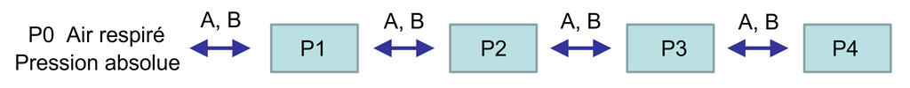

- Pour chaque compartiment, la **variation des** *“pressions”* **Pi** (c-à-d. les *tensions*  
  en air et non en gaz inerte) **est la différence entre ce qui rentre et ce qui sort**

**dP1/dt = A ( ( B + P0 + P1) ( P0 - P1 ) - ( B + P1 + P2 ) ( P1 - P2 ) )**

**dP2/dt = A ( ( B + P1 + P2 ) ( P1 - P2) - ( B + P2 + P3 ) ( P2 - P3 ) )**

**dP3/dt = A ( ( B + P2 + P3 ) ( P2 - P3 ) - ( B + P3 + P4 ) ( P3 – P4) )**

**dP4/dt = A ( B + P3 + P4 ) ( P3 – P4 )**

- Toutes les valeurs Pi sont exprimées en Pabs (unité msw = mètre eau de mer).  
  Les coefficients A et B sont les mêmes pour les 4 compartiments :  
  A = 0,0002596 et B = 83,67 (constantes de flux pour l’air, pas de temps dt=1mn)

Pascal Monestiez, octobre 2026, CC BY NC

## Détermination des Paliers ou SAD (Safe Ascent Depth)

- **Dans la première version Kidd et Stubbs 1971 :**  
  une seule formule donnant les limites avec 1 seul coefficient pour les 4 compartiments

  **SAD = Pi / R - Patm**

  coefficient **R= 1.8** qui correspond au **coeff. C = 2** de Haldane (donc un peu plus conservatif)
- **Dans la version DCIEM 1983 :**  
  une formule du type Droite de M-values pour les compartiments 1 et 2 seulement (soit deux coefficients chacun, l’équivalent des *a* et *b* de Bühlmann)

  **SAD = Pi / R - Offset - Patm**

  avec **R = 1,3 et Offset = 4,8** pour le premier compartiment  
  et **R = 1,385 et Offset = 2.5** pour le second compartiment
- Le SAD est la **profondeur plafond** qui donne directement **le palier en mètres**
- Les **vitesses de descente ET de remontée** sont de **18 m/mn**  
  devenues **15 m/mn** ( +/- **3 m/mn**) dans la version la plus récente

Pascal Monestiez, octobre 2026, CC BY NC

## Les astuces qui simplifient les calculs et le modèle

- **Les pressions sont mesurées en msw (mètres d’eau de mer)**  
  La pression hydrostatique correspond donc à la profondeur  
  La pression absolue est la profondeur + 10,06 msw (Patm ou Psl)
- **La gestion des gaz dissous dans les compartiments**  
  Les tensions modélisées ne sont PAS exprimées en pression partielle  
  du gaz neutre (N<sub>2</sub>) mais en pression absolue du compartiment  
  (cela évite d’avoir à multiplier ou diviser par 0.8 pour gérer les TN<sub>2</sub>)
- **Les limites SAD (Safe Ascent Depth)** sont calculées comme des pressions limites (SC) du compartiment, donc **DONNENT directement les profondeurs plafonds – ou de palier** – si on soustrait la Patm (ou Psl ou P at sea level).

Déconcertant mais efficace

Pascal Monestiez, octobre 2026, CC BY NC

## Exemple de simulations du DCIEM

**Animations avec charges et décharges ainsi que les flux**

Liens ci-dessous

- [Simulation DCIEM 60m 20mn](https://pmonestiez.github.io/dciem/anim1)
- [Simulation DCIEM 30m 50mn](https://pmonestiez.github.io/dciem/anim2)

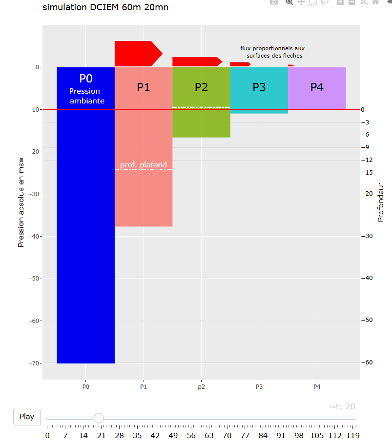

Pascal Monestiez, octobre 2026, CC BY NC

## Validation du DCIEM : des années 70’ aux 90’

- **Les essais se déroulent en milieu artificiel :**  
  pilotés par “ordinateur” XDC-1 puis XDC-2 (la remontée se fait en continu en suivant les indications sur l’écran)
- **Comparaisons de différentes conditions :**  
  conditions humides 5 à 10°C avec travail modéré et conditions sèches avec repos
- **Mesures systématiques du bullage à la sortie :**  
  sonde Doppler en zone sous-clavière (travaux avec le français G. Mazurel)

[figure not shown]

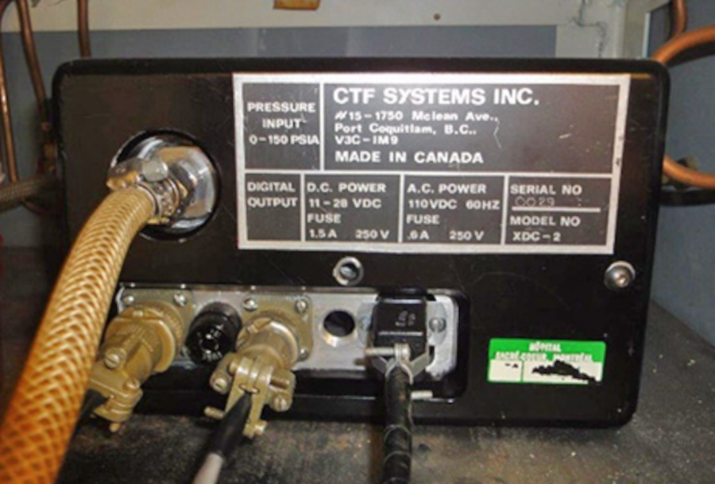

**Nishi R.Y. (1989)** Dive computer experience in Canada. in Lang and Hamilton (Eds.): AAUS DC Workshop. U.S.C. Sea Grant Program, Los Angeles, CA, p. 69-79. DCIEM 88-TR-37.

**Nishi R.Y., Kisman K.E., Buckingham I.P., Eatock B.C., Masurel G. (1980)** XDC-2 Digital decompression computer: Assement of decompression profiles by ultrasonic monitoring. Phase I. 36-54 msw. DCIEM No. 80-R-32, pp. 46.

**Nishi R.Y., Eatock B.C. Buckingham I.P., Masurel G. (1981)** XDC-2 Digital decompression computer: Assessment of decompression profiles by ultrasonic monitoring, Phase II: 30 - 75 msw. DCIEM Report No. 81-R-02, pp 45.

Pascal Monestiez, octobre 2026, CC BY NC

## Validation du DCIEM : des milliers de plongées

- **Gammes de durées et de profondeurs à l’air :**

  36m - 40 à 60mn; 45m - 20 à 35mn; 54m - 20 à 30mn

  Exceptionnal exposures: 45m - 70mn; 54m - 45mn; 63m - 30mn; 72 m - 40mn
- Désaturation à l’oxygène (en palier et/ou en surface)
- Plongées multi-niveaux et leurs tables avec PALIERS
- **Exemple de test en plongées successives** 45m 30mn SI=2h 45m 30mn
- plongées Heliox 84/16 dans les années 90 testées jusqu’à 100m
- **Non testés**: plongées en altitude (le modèle peut calculer mais n’a pas été testé), plus de 2 successives (rien dans le modèle ne s’y oppose), les “yoyos”

**Lauckner G.R., Nishi R.Y. and Eatock B.C. (1984)** Evaluation of the DCIEM 1983 decompression model for compressed  
air diving. DCIEM No. 84-R-73, pp. 30.

## Les 3 points essentiels qui caractérisent le DCIEM

- **Le nombre de compartiments et leur disposition**  
  4 compartiments disposés en série

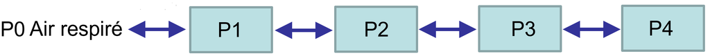

  (Pas Haldanien)
- **Les équations qui régissent les transferts entre compartiments**  
  L’équation du flux est non linéaire. La solution n’est plus exponentielle  
  La demi-vie dépend alors des pressions absolues  
  Il y a dissymétrie entre charge et décharge (Pas Haldanien)
- **Les limites SAD (Safe Ascent Depth)**  
  Modèle type droite de M-values pour le DCIEM 83  
  **SAD = P / R - Off - Patm** (Tout à fait Haldanien)

Pascal Monestiez, octobre 2026, CC BY NC

## L’équation de base du modèle

- **Flux de P1 vers P2 = A ( B + P1 + P2) ( P1 – P2 )**
- **Equation non-linéaire** et symétrique par rapport à P1 et P2 dans sa forme
- **(P1 – P2)** est le gradient, et si B devient très grand (A petit), on retrouve l’**équation de Haldane :** dP/dt = $\alpha \ \times$ (P1 - P2)
- **Une résolution numérique est nécessaire** (comme le pas de temps est grand, c’est-à-dire 1 minute, Kidd et Stubbs utilisent un Runge-Kutta d’ordre 4)*

**Nishi R. Y. et Kuehn L.A. (1973)** Digital computation of decompression profile. In DCIEM Report n° 884 23pp. (incluant le code FORTRAN en appendix)

* les ordis actuels avec un pas fin de quelques secondes (généralement non communiqué par le constructeur) utilisent probablement un Runge-Kutta d’ordre 1 plus simple

Pascal Monestiez, octobre 2026, CC BY NC

## L’équation de base du modèle (un peu plus loin)

- **Flux de P1 vers P2 = A ( B + P1 + P2) ( P1 – P2 )**
- Parler de période n’a pas vraiment de sens car la solution n’est pas l’exponentielle
- Une approximation donne pour Pi (initiale) et Pf (finale)

**T<sub>1/2</sub> = ln ( 2 – (Pf – Pi) / (B + Pi + Pf )) / (A (B + 2 Pf ))**

**La pseudo-période T<sub>1/2</sub> dépend de Pi et Pf**

- T<sub>1/2</sub> est plus courte si Pf > Pi (en charge) et plus longue si Pi > Pf (décharge)
- T<sub>1/2</sub> est plus courte si Pi et Pf sont grands et plus longue si Pi et Pf sont proches de la surface
- [Simulation de charge et décharge et calcul des pseudo-périodes](https://pmonestiez.github.io/dciem/exemple%2020.html)

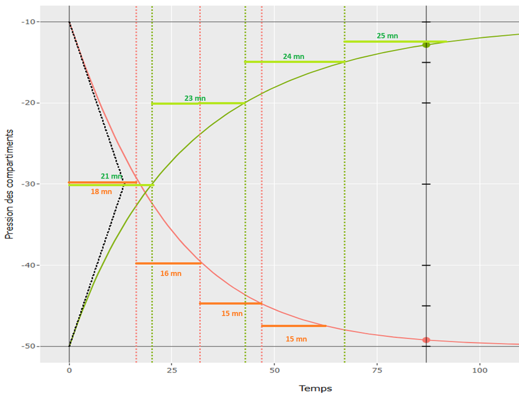

Pascal Monestiez, octobre 2026, CC BY NC

## L’équation de base du modèle (encore plus loin)

- **Flux de P1 vers P2 = A ( B + P1 + P2) ( P1 – P2 )**
- Hennessy (1973) montre qu’il s’agit de **l’approximation d’un modèle de diffusion** qui suit **la seconde loi de Fick** (équation de la diffusion) . Ce modèle de diffusion est celui utilisé par Hills (1967) pour modéliser les décompressimètres analogiques à membrane.
- L’**équation de diffusion** approximée au travers d’un schéma aux différences finies redonne l’**équation de Kidd et Stubbs 1971** (ci-dessus) pour une certaine forme du coefficient D de diffusion, où D est fonction linéaire de la pression.
- **Hennessy (1974)** discute l’intérêt de mêler **perfusion** (mod. Haldane) **et diffusion** (mod. Hills) pour coller aux expérimentations et données physiologiques  
  Cependant le **DCIEM** reste basé spécifiquement sur l’**approche diffusion** (Hills)

**Hennessy T. R. (1973)** The equivalent bulk-diffusion model of the pneumatic decompression computer. J. of Medical and biological Engeneering, 11, 135-137

**Hennessy T. R. (1974)** The interaction of perfusion and diffusion in homogeneous tissue. Bulletin of Mathematical Biology,  
36, 505-526

Pascal Monestiez, octobre 2026, CC BY NC

## Et les successives alors ?

- Le DCIEM **n’utilise pas de procédure type « majoration »** calculée sur un compartiment lent (MN90 T=120mn, Tables Buhlmann 86 T=77mn, …)
- **Il calcule vraiment les successives à partir de son modèle** : les compartiments P3 et P4 continuent à se charger bien après le retour en surface et sont encore chargés au début de la seconde plongée
- [**Exemple de simulation de plongées successives**](https://pmonestiez.github.io/dciem/anim21) avec le DCIEM
- Les tables DCIEM (**DCIEM Diving Manual, 1986**) peuvent induire en erreur avec des « groupes de successives ». Ces groupes ne sont pas utilisés pour le calcul de majorations, mais juste pour fournir une procédure de décompression sous forme de tables imprimées ou immergeables !

[figure not shown]

Pascal Monestiez, octobre 2026, CC BY NC

## Successives :comparaison aux autres modèles

- **les tables** (MN90, Bühlmann86, + plus anciennes) **: Principe de la majoration**  
  Nécessite de connaitre la profondeur de la seconde plongée  
  Nettement plus conservatif que le calcul du simple modèle haldanien.
- **les ordinateurs haldaniens ou néo-haldaniens** (ZHL-16C, RGBM, …)  
  L’ordinateur ne sait pas à quelle profondeur on va plonger. Et ne peut pas calculer de majoration sous forme d’un temps. Plusieurs possibilités:
  - ajout d’un conservatisme sur la seconde plongée, **en imposant un taux de désaturation constant pour tous les compartiments pendant l’intervalle**  
    (par exemple, le taux de désaturation du T 120 – **Cas A**, le plus fréquent)
  - **calcul simple de charge/décharge pour chaque compartiment durant l’intervalle**  
    et la seconde plongée (**Cas B**, souvent ordis teK).
- **Comparaison avec le DCIEM sur un exemple assez engagé:**  
  48m 20mn (Q = 215) – Intervalle 2h00 – 48m 20mn (Q = 215)

Pascal Monestiez, octobre 2026, CC BY NC

## 48m 20mn – Intervalle 2h00 – 48m 20mn

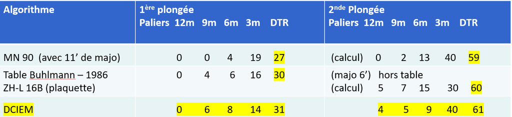

Dans ce cas, le DCIEM est proche des tables avec un conservatisme proche de celui obtenu par les calculs de majorations (MN90 ou Tables Bühlmann 86)

[figure not shown]

[figure not shown]

Pascal Monestiez, octobre 2026, CC BY NC

## 48m 20mn – Intervalle 2h00 – 48m 20mn

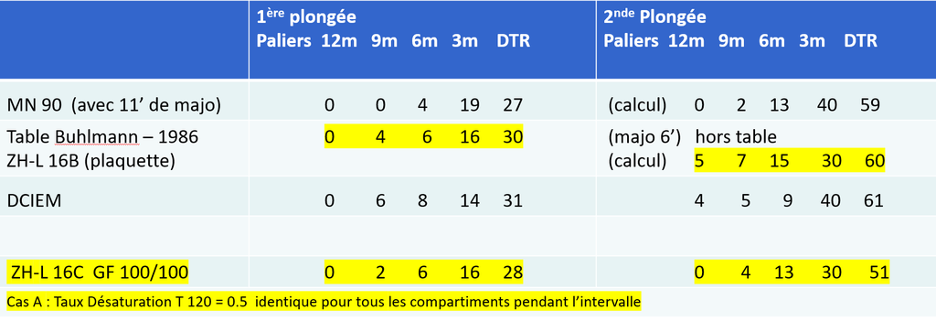

L’algorithme Bühlmann ZHL 16C reste cohérent avec les tables Bülhmann 86 pour la première plongée.  
Le conservatisme ajouté aux ordinateurs par un **taux de désaturation constant**  
(ici 0.5 si l’on prend en référence le T120) semble un peu moins important que pour les tables ou le DCIEM

Pascal Monestiez, octobre 2026, CC BY NC

## 48m 20mn – Intervalle 2h00 – 48m 20mn

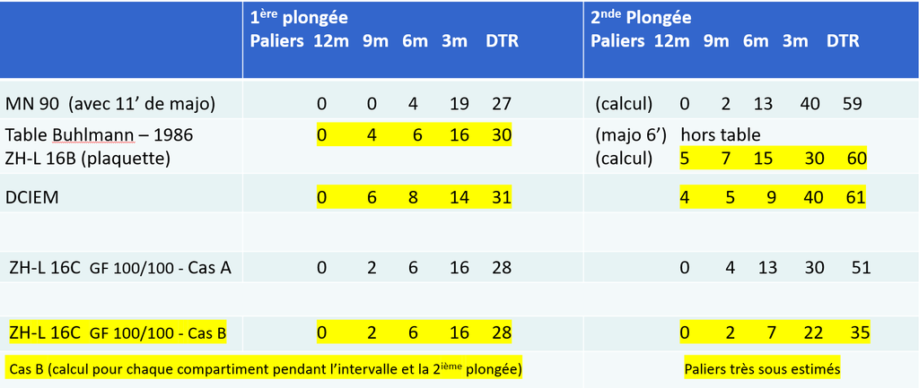

Le conservatisme de la procédure de majoration a disparu sur la seconde plongée.  
Le profil de décompression de la seconde plongée est à peine durci comparé a celui  
de la première plongée.

Pascal Monestiez, octobre 2026, CC BY NC

## Successives et DCIEM : que penser ?

- Le DCIEM donne des procédures de décompression similaires à celles des tables avec majorations (mais fait le calcul ce qui permet d’autres profils que les plongées carrées)
- Le DCIEM a été validé expérimentalement pour des successives variées et engagées. Il représente donc une solution très fiable
- Pour les autres ordinateurs, cela dépend des choix d’algorithmes implémentés par les fabriquants. Aller plus loin dans ces comparaisons nécessiterait des développements importants qui dépassent l’objet de cet exposé.
- Ajouter du conservatisme avec des GF symétriques 90-90 ou 85-85 est bien sûr une possibilté non-évaluée ici.

Pascal Monestiez, octobre 2026, CC BY NC

## En guise de synthèse

- **Simplicité** : Le DCIEM a seulement 6 parametres (3 pour le KS-1971). En comparaison, le ZHL-16C a presque 50 paramètres : [T,a,b]x16 + GF
- **Efficacité** : Le DCIEM couvre un large spectre de situations dont les successives multiples. Il apparait comme plutôt sûr car légèrement plus conservatif que la majorité des autres modèles et a une fiabilité semblable aux tables
- **Robustesse** : Il est utilisé depuis les années 80 dans le monde militaire et professionnel. Il n’a quasiment pas été modifié depuis son origine
- Sa simplicité et son efficience en terme de paramétrage lui confère **sur le plan mathématique** une **certaine élégance** en comparaison de tous les autres modèles

Pascal Monestiez, octobre 2026, CC BY NC

## Remerciements

Remerciements à Jean-Pierre Montseny et Alain Foret pour toutes les informations et documents qu’ils m’ont transmis, et pour tous les échanges enrichissants suscités

Merci aux documentalistes de Nantes Université pour avoir réussi à retrouver la trace d’articles scientifiques de plus de 50ans publiés dans des comptes-rendus de congrès

Les simulations du modèle et la résolution des équations différentielles ont été codées sous le logiciel R. Les graphiques et animations ont été réalisés avec les packages ggplot2 et ggplotly, et la présentation avec les environnements Quarto, Markdown et Revealjs

Cette présentation, d’autres supports et les animations sont accessibles sous  
**https://pmonestiez.github.io/dciem/**

Pascal Monestiez, octobre 2026, CC BY NC

## Références (modèle et théorie)

**Hills B.A (1967)** A pneumatic analogue for predicting the occurrence of decompression sickness. J. of Medical and biological Engeneering, 5, 421-432

**Kidd, D.J. and Stubbs R.A. (1969)** The use of the pneumatic analog computer for divers, in P.B. Bennett and D.H. Elliott, Eds., The Physiology and Medicine of Diving and Compressed Air Work, 1st ed., pp. 386-413, Bailliere, Tindall and Cassell, London.

**Kidd, D.J., Stubbs R.A. and Weaver R.S. (1971)** Comparative approaches to prophylactic decompression. In Underwater Physiology, Proceedings of the Fourth Symposium on Underwater Physiology, Ed. C.J. Lambertsen, pp. 167-177

**Nishi R. Y. et Kuehn L.A. (1973)** Digital computation of decompression profile. In DCIEM Report n° 884, Defence and Civil Institute of Environmental Medicine, Downsview, Ontario, pp. 23pp. (including FORTRAN code in appendix)

**Hennessy T. R. (1973)** The equivalent bulk-diffusion model of the pneumatic decompression computer. J. of Medical and biological Engeneering, 11, 135-137

**Hennessy T. R. (1974)** The interaction of perfusion and diffusion in homogeneous tissue. Bulletin of Mathematical Biology, 36, 505-526

**Hennessy T. R. and Hempleman H. V. (1977)** An Examination of the Critical Released Gas Volume Concept in Decompression Sickness, Proc. R. Soc. Lond. B, 197, 299-313. doi: 10.1098/rspb.1977.0072

**Nishi R.Y. and Lauckner G.R. (1984)** Development of the DCIEM 1983 decompression model for compressed air diving. DCIEM No. 84-R-44, Defence and Civil Institute of Environmental Medicine, Downsview, Ontario, pp. 54.

**DCIEM Diving Manual (1986)** Air décompression procedures and tables. DCIEM No. 86-R-35, Ed. Department of National Defence (Canada), Defence and Civil institute of Environmental Medicine (DCIEM), and Universal Dive Techtronics, Inc. (UDT), pp. 347

**DCIEM Diving Manual Part 2 (1992)** Helium-oxygen surface-supplied decompression procedures and table DCIEM No. 92-50, Ed. Department of National Defence (Canada), Defence and Civil institute of Environmental Medicine (DCIEM), pp. 114

Pascal Monestiez, octobre 2026, CC BY NC

## Références (essais et validation)

**Kooner M.D., Ridgewell B.A. (1979)** Diving computer operational envelope proving protocol Phase 1. XDC-2 validation dives 0-54 msw. June July 1979. DCIEM-TC-79C33

**Kisman K.E., Masurel G., Guillerm R. (1979)** A doppler ultrasonic data bank for diver decompression analysis, DCIEM Report No. 79-R-28, pp 37.

**Kooner M.D. (1980)** Diving decompression computer (XDC-2) Validation dives, 36 - 54 msw, phase I preliminary results. DCIEM TC 80-C-12, pp 36.

**Nishi R.Y., Kisman K.E., Eatock B.C. Buckingham I.P., Masurel G. (1981)** XDC-2 Digital decompression computer: Assessment of decompression profiles by ultrasonic monitoring, Phase I : 36 - 54 msw. DCIEM Report No. 80-R-32, pp 47.

**Nishi R.Y., Eatock B.C. Buckingham I.P., Masurel G. (1981)** XDC-2 Digital decompression computer: Assessment of decompression profiles by ultrasonic monitoring, Phase II: 30 - 75 msw. DCIEM Report No. 81-R-02, pp 45.

**Lauckner G.R., Nishi R.Y. and Eatock B.C. (1984)** Evaluation of the DCIEM 1983 decompression model for compressed air diving. DCIEM No. 84-R-73, pp. 30.

**Nishi R.Y. (1989)** Dive computer experience in Canada. in Lang and Hamilton (Eds.): AAUS DC Workshop. U.S.C. Sea Grant Program, Los Angeles, CA, p. 69-79. DCIEM 88 - TR - 37.

**Nishi R.Y. (1991)** Design of decompression trials - DCIEM expérience (with discussion). in Lang and Vann (Eds.): AAUS Repetitive Diving Workshop. Duke University, U.S.C. Sea Grant Program, March 91, p 311:323.

(je recherche toujours des pubs ou rapports décrivant essais et résultats)

Pascal Monestiez, octobre 2026, CC BY NC

## **Place aux QUESTIONS … sur le DCIEM**

- **Simplicité** : seulement 6 parametres et une base physique/physiologique
- **Efficacité** : un large spectre de situations dont les successives, très fiable et aussi sûr que les tables.
- **Robustesse** : testé depuis les années 80 sur des plongées engagées et quasiment pas modifié depuis son origine
- **Spécificité** et élégance **mathématique** en comparaison de tous les autres modèles

Cette présentation, d’autres supports et les animations sont accessibles sous  
**https://pmonestiez.github.io/dciem/**

Pascal Monestiez, octobre 2026, CC BY NC